# Assignment ARIMA

2023-11-22

```r
library(fpp)
library(fpp2)
```

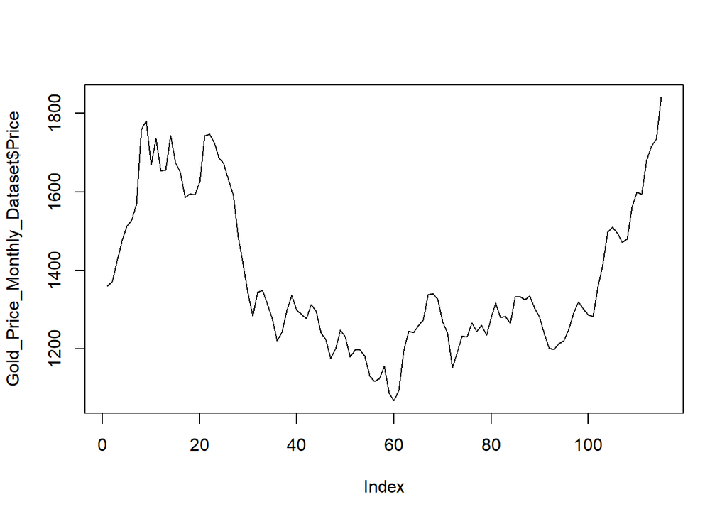

```r
library(readxl)
Gold_Price_Monthly_Dataset <- read_excel("C:/Users/mumba/Desktop/Gold_Price_Monthly_Dataset.xls")
View(Gold_Price_Monthly_Dataset)

plot(Gold_Price_Monthly_Dataset$Price, type = "l")
```

This is a line graph that is showing the price of Gold on January, 2011 till Juy, 2020

```r
head(x=Gold_Price_Monthly_Dataset$Date, y=Gold_Price_Monthly_Dataset$Price,type="l")
```

```
## [1] "2011-01-01 UTC" "2011-02-01 UTC" "2011-03-01 UTC" "2011-04-01 UTC"
## [5] "2011-05-01 UTC" "2011-06-01 UTC"
```

```r
#Convert into time series
ts_data_new <- ts(Gold_Price_Monthly_Dataset$Price, start = c(2011, 1), frequency = 12)
```

tdisplay shows the ACF, PACF and time series plot

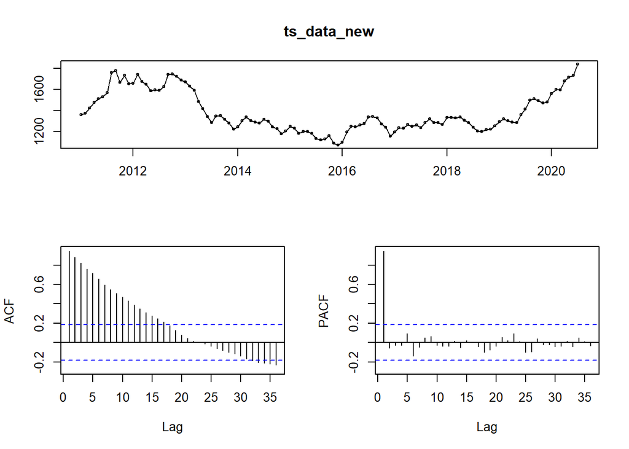

```r
tsdisplay(ts_data_new)
```

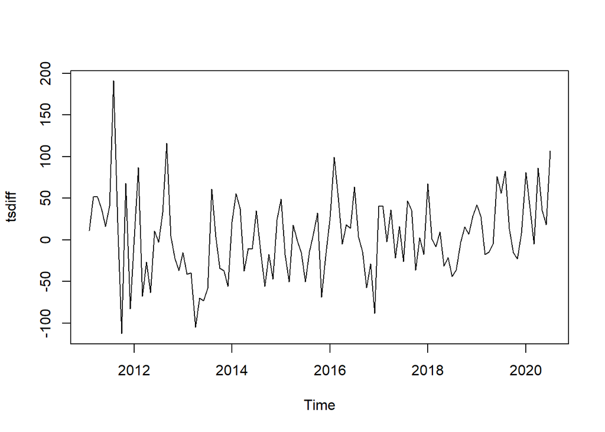

```r
tsdiff <- diff(ts_data_new, differences = 1)
plot(tsdiff)
```

The diff function is employed to calculate the disparities between successive elements in a numeric vector or matrix.

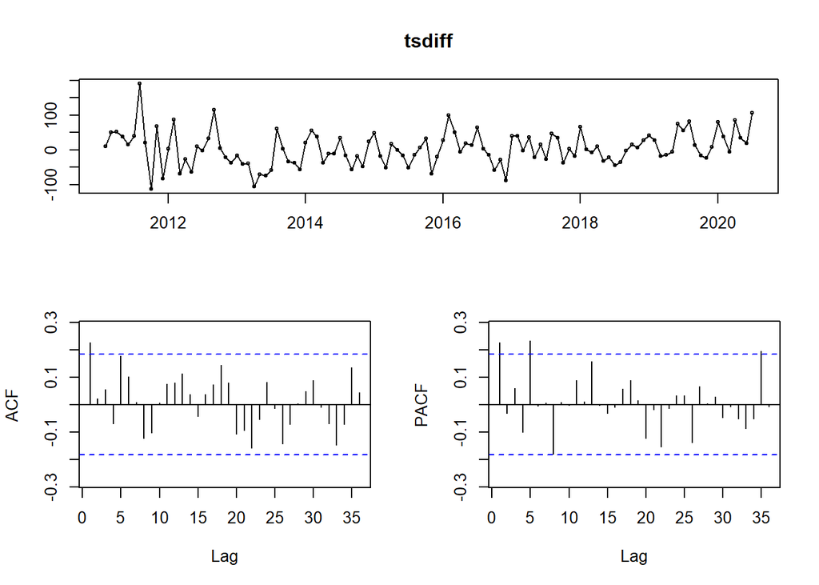

```r
tsdisplay(tsdiff)
```

```r
auto_fit <- auto.arima(ts_data_new, trace=TRUE, stepwise = FALSE)
```

```
##
##  ARIMA(0,1,0)                               : 1211.325
##  ARIMA(0,1,0)            with drift         : 1212.54
##  ARIMA(0,1,0)(0,0,1)[12]                    : 1212.611
##  ARIMA(0,1,0)(0,0,1)[12] with drift         : 1213.805
##  ARIMA(0,1,0)(0,0,2)[12]                    : 1213.787
##  ARIMA(0,1,0)(0,0,2)[12] with drift         : 1214.832
##  ARIMA(0,1,0)(1,0,0)[12]                    : 1212.456
##  ARIMA(0,1,0)(1,0,0)[12] with drift         : 1213.626
##  ARIMA(0,1,0)(1,0,1)[12]                    : Inf
##  ARIMA(0,1,0)(1,0,1)[12] with drift         : Inf
##  ARIMA(0,1,0)(1,0,2)[12]                    : Inf
##  ARIMA(0,1,0)(1,0,2)[12] with drift         : Inf
##  ARIMA(0,1,0)(2,0,0)[12]                    : 1213.672
##  ARIMA(0,1,0)(2,0,0)[12] with drift         : 1214.751
##  ARIMA(0,1,0)(2,0,1)[12]                    : Inf
##  ARIMA(0,1,0)(2,0,1)[12] with drift         : Inf
##  ARIMA(0,1,0)(2,0,2)[12]                    : Inf
##  ARIMA(0,1,0)(2,0,2)[12] with drift         : Inf
##  ARIMA(0,1,1)                               : 1206.661
##  ARIMA(0,1,1)            with drift         : 1208.131
##  ARIMA(0,1,1)(0,0,1)[12]                    : 1208.47
##  ARIMA(0,1,1)(0,0,1)[12] with drift         : 1209.953
##  ARIMA(0,1,1)(0,0,2)[12]                    : 1209.235
##  ARIMA(0,1,1)(0,0,2)[12] with drift         : 1210.582
##  ARIMA(0,1,1)(1,0,0)[12]                    : 1208.397
##  ARIMA(0,1,1)(1,0,0)[12] with drift         : 1209.87
##  ARIMA(0,1,1)(1,0,1)[12]                    : Inf
##  ARIMA(0,1,1)(1,0,1)[12] with drift         : Inf
##  ARIMA(0,1,1)(1,0,2)[12]                    : 1211.406
##  ARIMA(0,1,1)(1,0,2)[12] with drift         : 1212.787
##  ARIMA(0,1,1)(2,0,0)[12]                    : 1209.277
##  ARIMA(0,1,1)(2,0,0)[12] with drift         : 1210.667
##  ARIMA(0,1,1)(2,0,1)[12]                    : Inf
##  ARIMA(0,1,1)(2,0,1)[12] with drift         : Inf
##  ARIMA(0,1,1)(2,0,2)[12]                    : Inf
##  ARIMA(0,1,1)(2,0,2)[12] with drift         : Inf
##  ARIMA(0,1,2)                               : 1208.619
##  ARIMA(0,1,2)            with drift         : 1210.099
##  ARIMA(0,1,2)(0,0,1)[12]                    : 1210.426
```

[output cut: 142 more lines]

```
##  ARIMA(3,1,2)            with drift         : Inf
##  ARIMA(4,1,0)                               : 1211.814
##  ARIMA(4,1,0)            with drift         : 1213.419
##  ARIMA(4,1,0)(0,0,1)[12]                    : 1213.669
##  ARIMA(4,1,0)(0,0,1)[12] with drift         : 1215.29
##  ARIMA(4,1,0)(1,0,0)[12]                    : 1213.571
##  ARIMA(4,1,0)(1,0,0)[12] with drift         : 1215.183
##  ARIMA(4,1,1)                               : Inf
##  ARIMA(4,1,1)            with drift         : Inf
##  ARIMA(5,1,0)                               : 1207.527
##  ARIMA(5,1,0)            with drift         : 1209.217
##
##
##
##  Best model: ARIMA(0,1,4)
```

1. Output Summary: The ARIMA(0,1,4) model is used for predicting future values in a time series. It doesn’t rely on past values directly, but it does use the difference between consecutive values to make the data more predictable (achieve stationarity). Additionally, it considers the last four forecast errors to better capture and adjust for random fluctuations or residual errors in the data.

```r
auto_fit
```

```
## Series: ts_data_new
## ARIMA(0,1,4)
##
## Coefficients:
##          ma1     ma2     ma3      ma4
##       0.3445  0.0021  0.1227  -0.2381
## s.e.  0.0917  0.1003  0.0897   0.1128
##
## sigma^2 = 2159:  log likelihood = -597.64
## AIC=1205.28   AICc=1205.84   BIC=1218.96
```

auto_fit is commonly linked with functions or processes designed to automatically identify the most suitable model for a given time series. The sigma square is 2159 for the model.

```r
#Each attributes
attributes(auto_fit)
```

```
## $names
##  [1] "coef"      "sigma2"    "var.coef"  "mask"      "loglik"    "aic"
##  [7] "arma"      "residuals" "call"      "series"    "code"      "n.cond"
## [13] "nobs"      "model"     "bic"       "aicc"      "x"         "fitted"
##
## $class
## [1] "forecast_ARIMA" "ARIMA"          "Arima"
```

3. Perform and Plot the forecast for the next five periods.

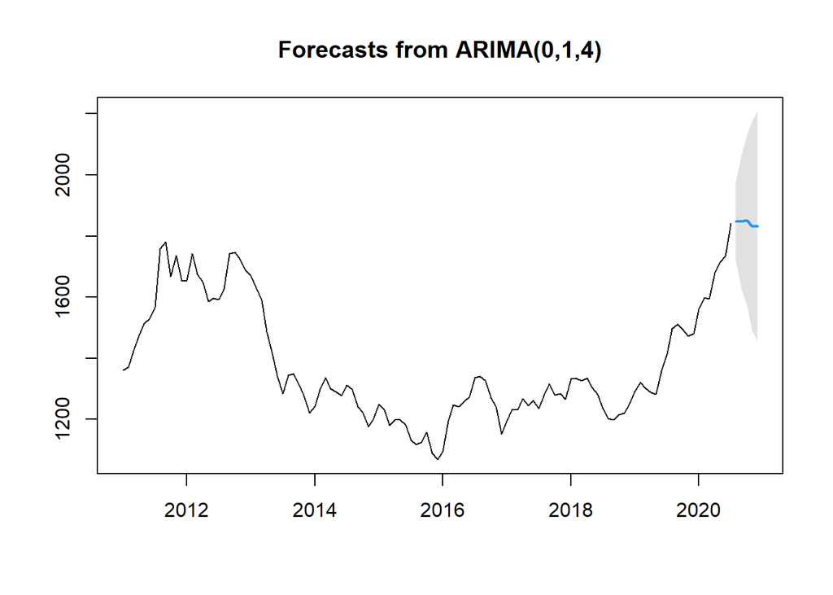

```r
plot(forecast(auto_fit,h=5,level=c(99.5)))
```

The forecast for the next five periods seems to be constant with slightly decrease in the price.

2.RESIDUAL ANALYSIS

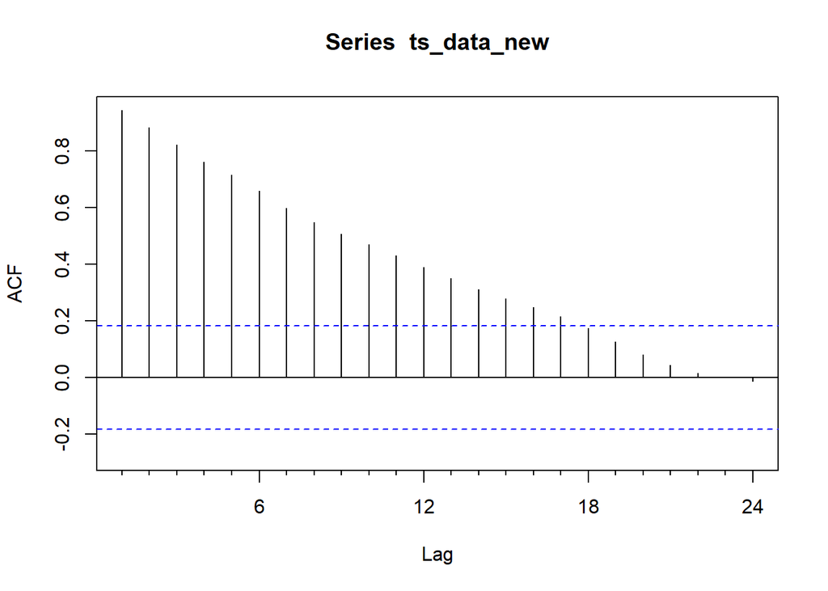

```r
Acf(ts_data_new)
```

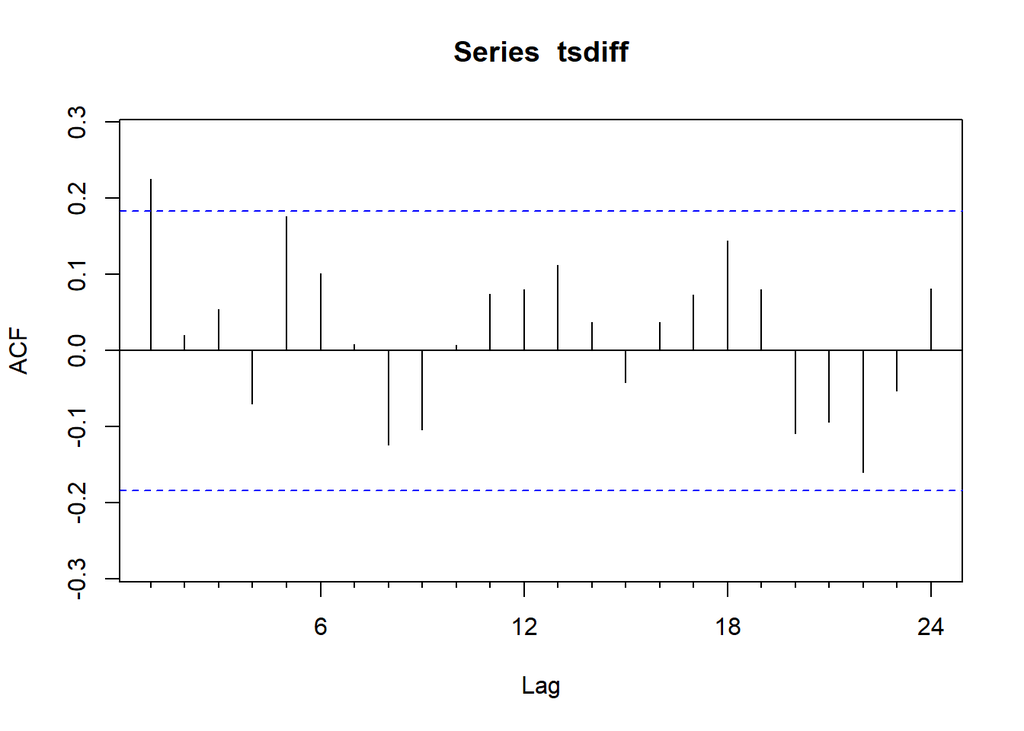

```r
Acf(tsdiff)
```

The ACF of residual analysis for my data shows no seasonal trend. It shows the random data

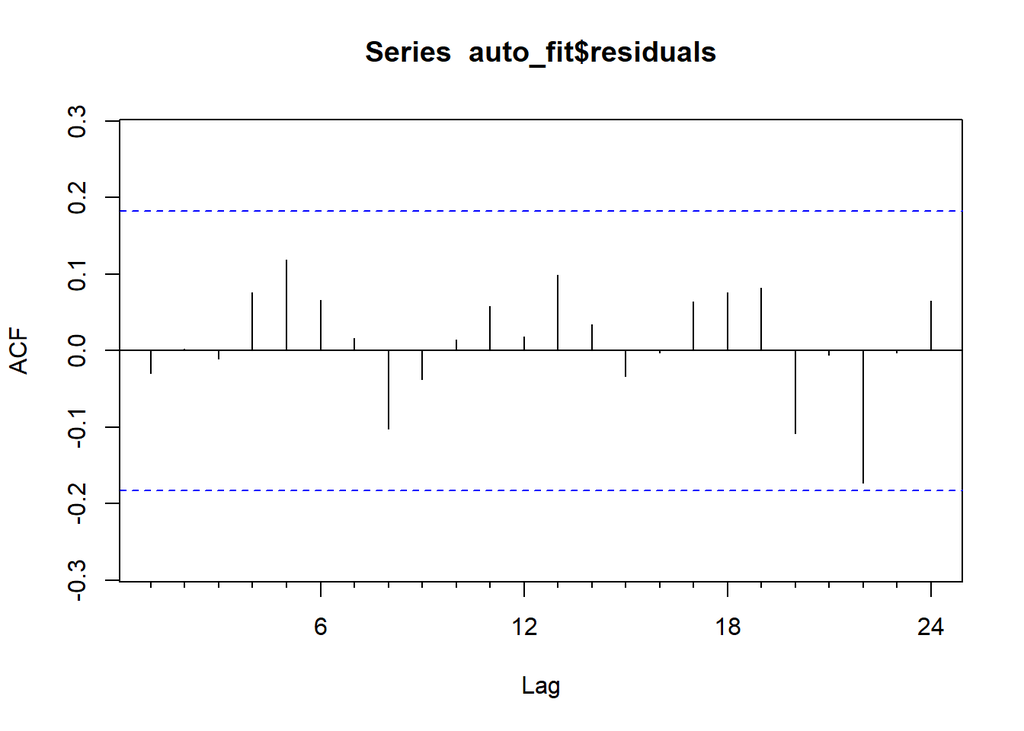

```r
Acf(auto_fit$residuals)
```

```r
Box.test(residuals(auto_fit), lag=20, type="Ljung")
```

```
##
##  Box-Ljung test
##
## data:  residuals(auto_fit)
## X-squared = 10.652, df = 20, p-value = 0.9548
```

Box.test is a statistical test that helps us see if there’s a pattern of repeating values in a time series. It gives us information like the chi-squared statistic, degrees of freedom, and p-value.

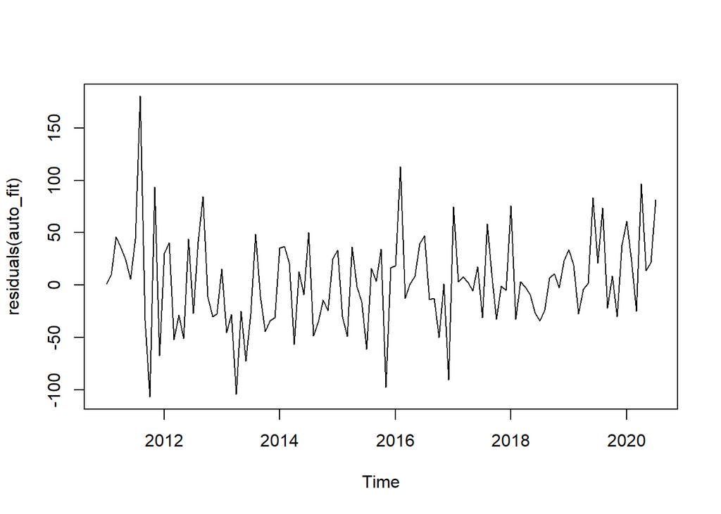

```r
plot.ts(residuals(auto_fit))
```

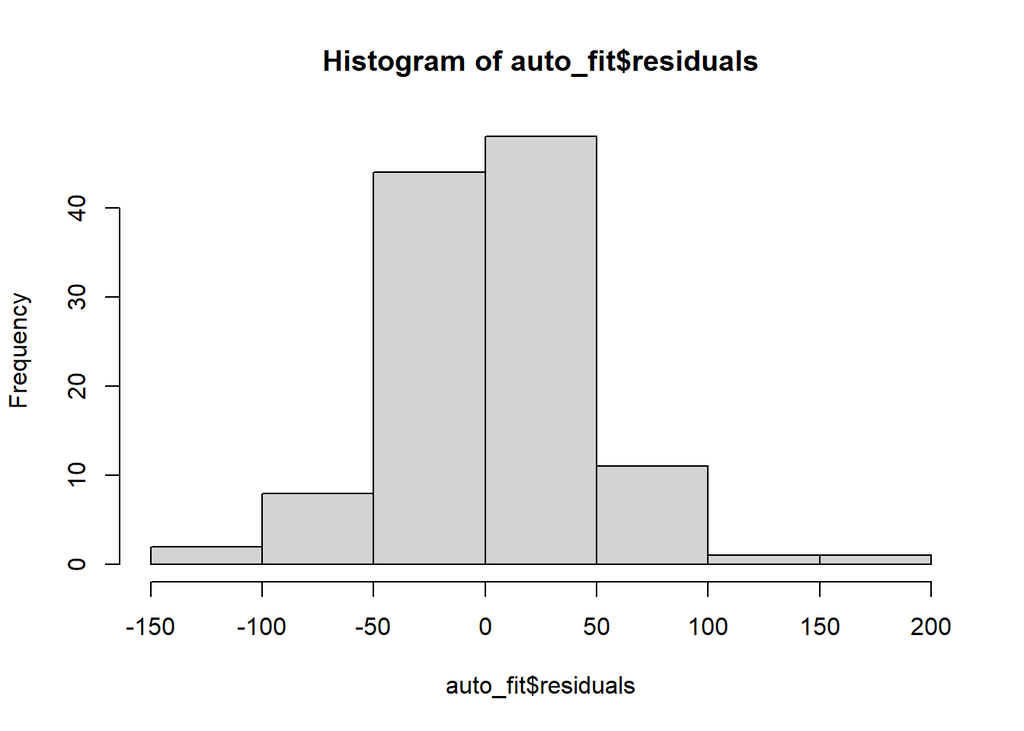

```r
hist(auto_fit$residuals)
```

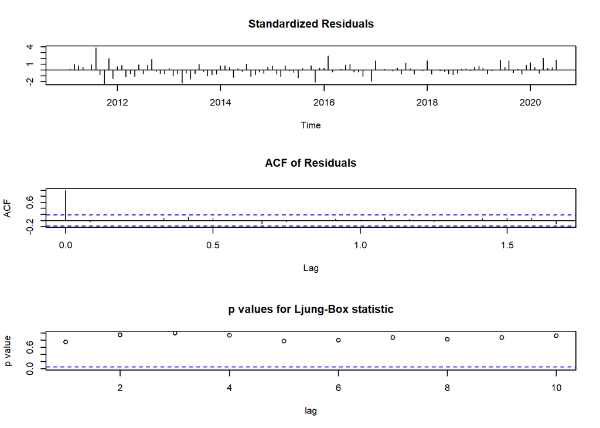

```r
tsdiag(auto_fit)
```

There is no seasonal data.

4. Show the accuracy of your ARIMA model

```r
accuracy(auto_fit)
```

```
##                    ME     RMSE      MAE       MPE     MAPE      MASE
## Training set 3.336958 45.44092 34.44517 0.1731718 2.465024 0.2399438
##                     ACF1
## Training set -0.02986367
```